# STAT184 final project

Sooyoul Lee

2017-11-25

*Source file* ⇒ 184_project.Rmd

# Introdcution

The H-1B is a visa in the United States which allows U.S employers to employ foreign workers in specialty occupations. It is very hard to work in United States as International Students. Therefore, Since I am an internatioal student, I would like to know who receive H-1b visa, which companies provide H-1b most, and more. Finally, I have obtained the data from http://www.flcdatacenter.com which provides various information about foreign labors.

# Data describtion

**CaseNumber**: Applicants’ Case number

**CaseStatus**: Status associated with the last significant event or decision. Valid values include “Certified” “Certified-Withdrawn” “Denied” and “Withdrawn”. **Note**: Certified does not mean this person gets H1-B visa. It means he is eligible to apply for H1-B visa.

**JobTitle**: Title of the job. e.g., Data Scientist, Data Engineer etc.

**EmployerName**: Name of employer submitting the H1-B application.

**Wage**: The wage for a job position

**FullTimePosition**: To distinguish that it is partime job or fulltime job.

First, read csv file

```r
#Since the class for "Prevailing_Wage was character I change it to numeric by using following"
H1B <- read_csv("H-1B_Disclosure_Data_FY17.csv",col_types = cols(PREVAILING_WAGE = col_number()))
```

```r
#I extract the variables that I need for my data
H1B_Sorted <-
  H1B %>%
  select(CASE_NUMBER, CASE_STATUS, JOB_TITLE, EMPLOYER_NAME, PREVAILING_WAGE, FULL_TIME_POSITION) %>%
  rename(CaseNumber = CASE_NUMBER, CaseStatus = CASE_STATUS, JobTitle = JOB_TITLE, EmployerName = EMPLOYER_NAME, Wage = PREVAILING_WAGE, FullTimePosition = FULL_TIME_POSITION)

#showing above 10 rows from "H1B_Sorted" table
H1B_Sorted[c(1:10),]
```

```
## # A tibble: 10 x 6
##            CaseNumber          CaseStatus
##                 <chr>               <chr>
##  1 I-200-16055-173457 CERTIFIED-WITHDRAWN
##  2 I-200-16064-557834 CERTIFIED-WITHDRAWN
##  3 I-200-16063-996093 CERTIFIED-WITHDRAWN
##  4 I-200-16272-196340           WITHDRAWN
##  5 I-200-15053-636744 CERTIFIED-WITHDRAWN
##  6 I-200-15071-336195 CERTIFIED-WITHDRAWN
##  7 I-200-16056-842817 CERTIFIED-WITHDRAWN
##  8 I-200-16056-757335 CERTIFIED-WITHDRAWN
##  9 I-200-16058-469533 CERTIFIED-WITHDRAWN
## 10 I-200-16059-084066 CERTIFIED-WITHDRAWN
## # ... with 4 more variables: JobTitle <chr>, EmployerName <chr>,
## #   Wage <dbl>, FullTimePosition <chr>
```

```r
#H1B_Status shows that how many applicants were qaulifying for applying for H1-B visa or not
H1B_Status <-
  H1B_Sorted %>%
  group_by(CaseStatus) %>%
  summarise(NumberOfEachStatus = n()) %>%
  arrange(desc(NumberOfEachStatus))
```

# Which Employers submit the most number of H-1B visa applications?

```r
#H1B_Most shows Top10 of Companies that submit the most number of H-1B visa and wages.
H1B_Most <-
  H1B_Sorted %>%
  group_by(EmployerName) %>%
  summarise(NumberOfApplications = n(), MeanWage = mean(Wage)) %>%
  arrange(desc(NumberOfApplications)) %>%
  head(10)

#Displaying Top10 campanies' number of applications and mean wages.
H1B_Most
```

```
## # A tibble: 10 x 3
##                         EmployerName NumberOfApplications  MeanWage
##                                <chr>                <int>     <dbl>
##  1                   INFOSYS LIMITED                20587  76559.33
##  2 TATA CONSULTANCY SERVICES LIMITED                13529  65047.01
##  3             CAPGEMINI AMERICA INC                 9604  74123.81
##  4         IBM INDIA PRIVATE LIMITED                 8734  69862.96
##  5     TECH MAHINDRA (AMERICAS),INC.                 7543  74957.19
##  6           DELOITTE CONSULTING LLP                 7179  76819.94
##  7                     ACCENTURE LLP                 6690  81685.75
##  8            ERNST & YOUNG U.S. LLP                 6096  74942.69
##  9                     WIPRO LIMITED                 5177  74734.04
## 10                       GOOGLE INC.                 5074 107781.28
```

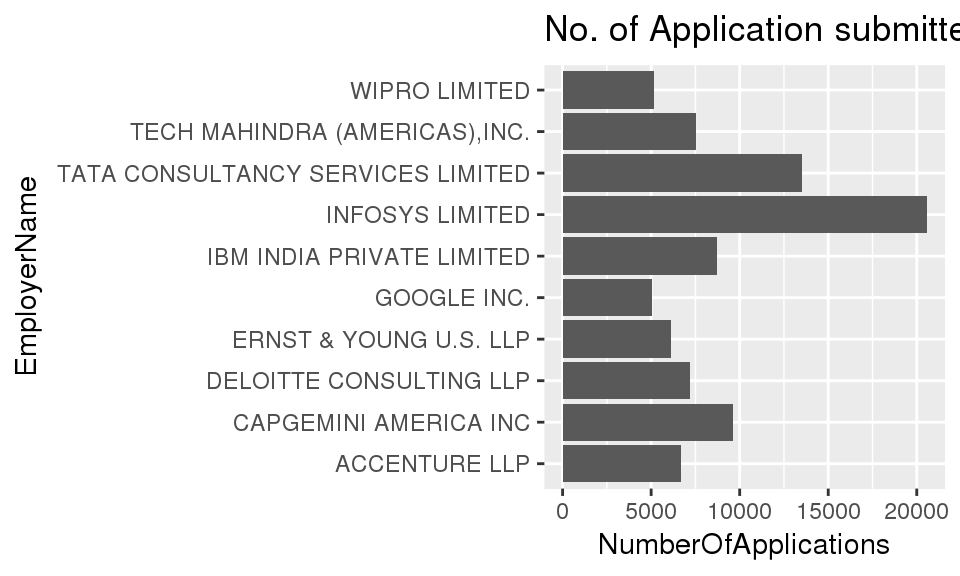

```r
#Producing Bar graph of number of applications for Top10 companies
H1B_Most %>%
  ggplot(aes(x = EmployerName, y = NumberOfApplications)) +
  ggtitle("No. of Application submitted TOP10 Companies") +
  geom_bar(stat="identity") +
  theme(axis.text.y=element_text(hjust=1)) +
  coord_flip()
```

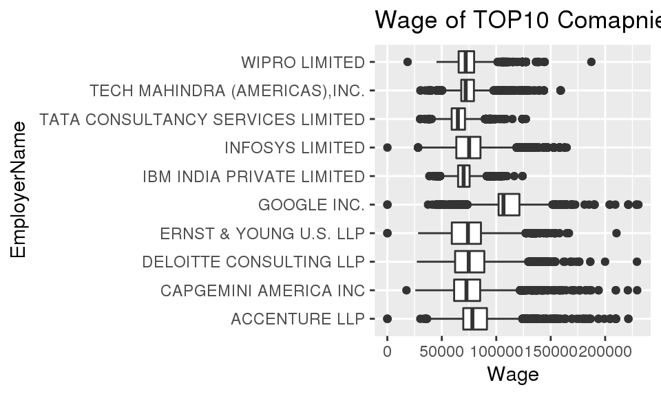

```r
#Top10Most only extracts rows that are related to Top10 Comapnies from H1B_Sorted table
Top10Most <- subset(H1B_Sorted, EmployerName %in% c("ACCENTURE LLP","INFOSYS LIMITED","TATA CONSULTANCY SERVICES LIMITED","CAPGEMINI AMERICA INC","IBM INDIA PRIVATE LIMITED","TECH MAHINDRA (AMERICAS),INC.","DELOITTE CONSULTING LLP","ERNST & YOUNG U.S. LLP","WIPRO LIMITED","GOOGLE INC."))

#Displaying Wage offered from Top10 Companies by using Boxplot
Top10Most %>%
  ggplot(aes(x = EmployerName, y = Wage)) +
  ggtitle("Wage of TOP10 Comapnies") +
  geom_boxplot() +
  coord_flip()
```

## What kind of jobs provide H1B visa most?

```r
#H1B_Jobs shows Top10 of Job title that submit the most number of H-1B visa and wages.
H1B_Jobs <-
  H1B_Sorted %>%
  group_by(JobTitle) %>%
  summarise(TotalNumberOfApplications = n(), MeanWage = mean(Wage, na.rm=TRUE)) %>%
  arrange(desc(TotalNumberOfApplications)) %>%
  head(10)

#Displaying Top10 Jobtitles
H1B_Jobs
```

```
## # A tibble: 10 x 3
##                    JobTitle TotalNumberOfApplications  MeanWage
##                       <chr>                     <int>     <dbl>
##  1       PROGRAMMER ANALYST                     47151  61812.25
##  2        SOFTWARE ENGINEER                     27950  82286.57
##  3       SOFTWARE DEVELOPER                     16107  69758.48
##  4          SYSTEMS ANALYST                     10798  65767.53
##  5         BUSINESS ANALYST                      7410  58045.89
##  6      COMPUTER PROGRAMMER                      7303  61280.71
##  7 SENIOR SOFTWARE ENGINEER                      6983 103940.87
##  8 COMPUTER SYSTEMS ANALYST                      6555  66565.19
##  9                DEVELOPER                      5835  66692.26
## 10      ASSISTANT PROFESSOR                      4957  61174.22
```

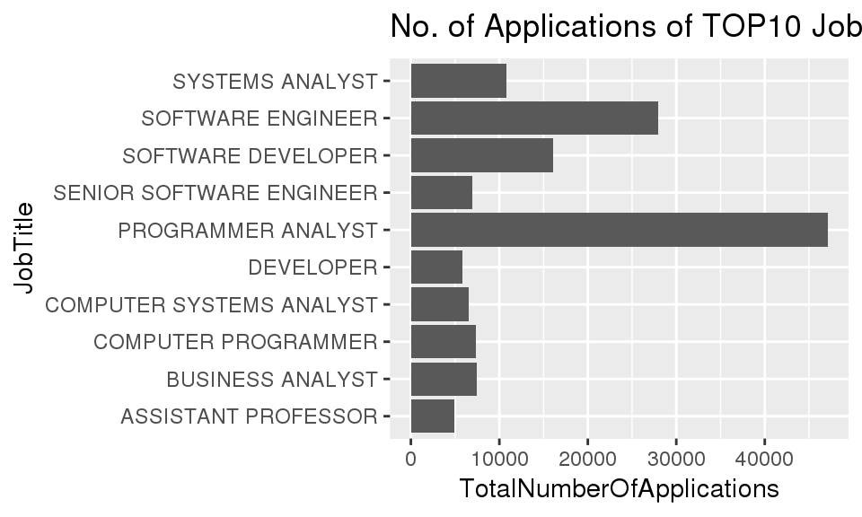

```r
#Producing bar graph displaying number of applications submitted for Top10 Jobtitle
H1B_Jobs %>%
  ggplot(aes(x = JobTitle, y = TotalNumberOfApplications)) +
  ggtitle("No. of Applications of TOP10 Jobs") +
  geom_bar(stat="identity") +
  theme(axis.text.y=element_text(hjust=1)) +
  coord_flip()
```

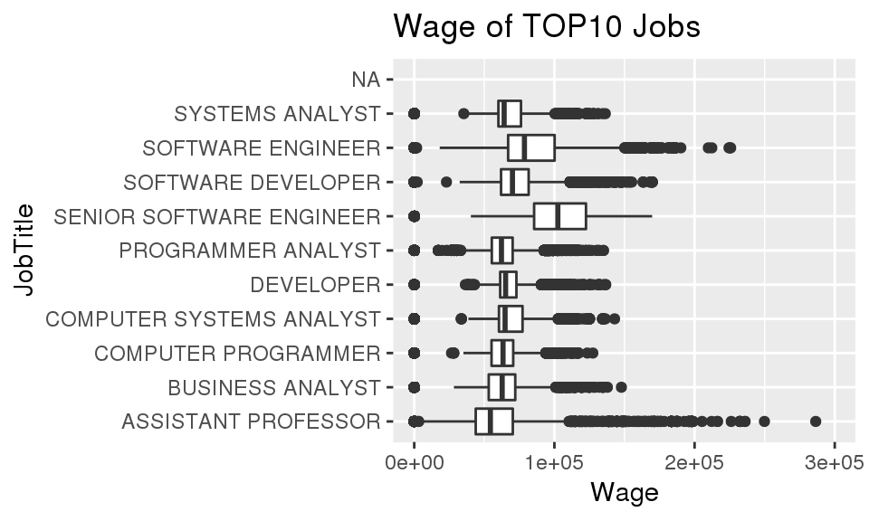

```r
#Top10Job only extracts rows that are related to Top10 Jobtitle from H1B_Sorted table
Top10Job <- subset(H1B_Sorted, JobTitle %in% c("PROGRAMMER ANALYST",
                                               "SOFTWARE ENGINEER",
                                               "SOFTWARE DEVELOPER",
                                               "SYSTEMS ANALYST",
                                               "BUSINESS ANALYST",
                                               "COMPUTER PROGRAMMER",
                                               "SENIOR SOFTWARE ENGINEER",
                                               "COMPUTER SYSTEMS ANALYST",
                                               "DEVELOPER","ASSISTANT PROFESSOR"))

#Removing unecessary data
Top10Job1 <- Top10Job[Top10Job$Wage!=743590 & Top10Job$Wage!=544662 & Top10Job$Wage!=524778, ]

#Displaying Wage offered from Top10 JobTitle by using Boxplot
Top10Job1 %>%
  ggplot(aes(x = JobTitle, y = Wage)) +
  ggtitle("Wage of TOP10 Jobs") +
  geom_boxplot() +
  ylim(c(0,300000)) +
  coord_flip()
```

## Conclusion

*I could see companies that submit most applcations were mostly IT related company. Also, I can see almost same result from JobTitle, too. The top 10 job titles that I extracted based on number of applications show that most of them are IT based occupations

*Also, If we see the box plots for each cases. We can see that average wage is approximately $70,000 which is very high and they should mostly earn those amount to qualitfy H1-B visa